# Bias-Variance Tradeoff & Discriminant Analysis

k-Nearest Neighbours vs. Linear Discriminant Analysis

Ducheng Tan

STAT 547 — Data Mining | RIT, Spring 2026

```r
library(ggplot2)
library(kknn)
library(MASS)
library(patchwork)
```

# 1 Overview

This report illustrates two foundational concepts in supervised statistical learning:

1. **Bias-Variance Tradeoff in k-NN** — how model complexity (controlled by $k$) governs the tradeoff between underfitting and overfitting, visualized through model complexity and expected prediction error curves.
2. **Decision Boundary Comparison: k-NN vs. LDA** — empirical comparison of a non-parametric (k-NN) and a parametric (LDA) classifier on overlapping Gaussian classes, connecting geometric intuition to theoretical assumptions.

# 2 The Bias-Variance Tradeoff in k-NN

## 2.1 Model Complexity vs. $k$

In k-Nearest Neighbours, model complexity is inversely proportional to $k$. At $k=1$ the model interpolates perfectly through every training point (maximum variance, zero bias); as $k \to n$ the model collapses to a constant prediction (maximum bias, zero variance).

A natural proxy for effective complexity is $\frac{1}{k}$, since increasing $k$ smooths the decision boundary and reduces the effective number of free parameters.

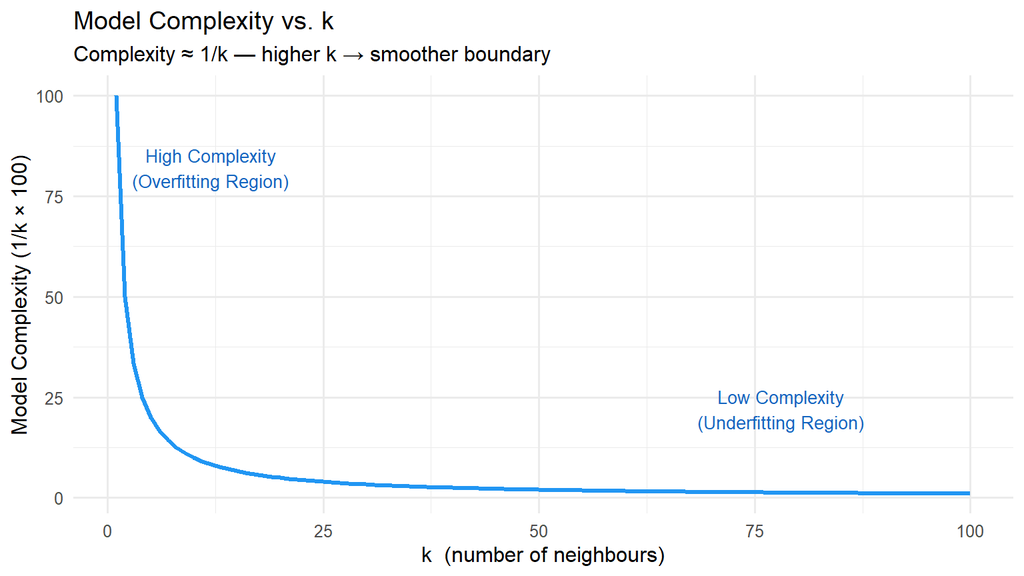

```r
k_vals     <- 1:100
complexity <- 100 / k_vals
df_c       <- data.frame(k = k_vals, Complexity = complexity)

p1 <- ggplot(df_c, aes(x = k, y = Complexity)) +
  geom_line(color = "#2196F3", linewidth = 1.2) +
  annotate("text", x = 12, y = 82,
           label = "High Complexity\n(Overfitting Region)",
           color = "#1565C0", size = 3.5) +
  annotate("text", x = 78, y = 22,
           label = "Low Complexity\n(Underfitting Region)",
           color = "#1565C0", size = 3.5) +
  labs(title = "Model Complexity vs. k",
       subtitle = "Complexity ≈ 1/k — higher k → smoother boundary",
       x = "k  (number of neighbours)",
       y = "Model Complexity (1/k × 100)") +
  theme_minimal(base_size = 12)

p1
```

## 2.2 Expected Prediction Error vs. $k$

The total expected prediction error decomposes as:
$$\text{EPE}(k) = \text{Bias}^2(k) + \text{Variance}(k) +
\sigma^2_\varepsilon$$

- **Low $k$** (left): low bias, high variance → the model memorizes noise.
- **High $k$** (right): high bias, low variance → the model over-smooths.
- **Optimal $k$**: the $k$ minimising test error, balancing both terms.

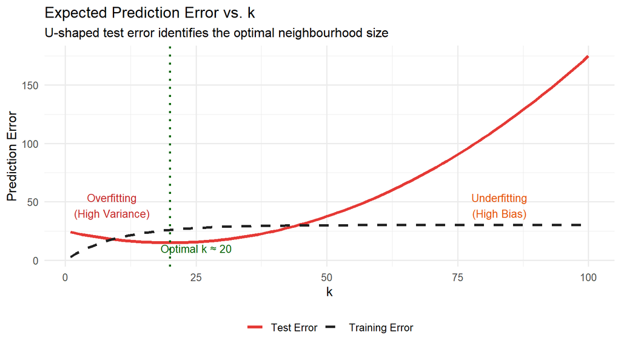

```r
k_seq       <- seq(1, 100, length.out = 100)
test_error  <- (k_seq - 20)^2 / 40 + 15
train_error <- 30 * (1 - exp(-0.1 * k_seq))

df_err <- data.frame(
  k           = k_seq,
  Test_Error  = test_error,
  Train_Error = train_error
)

p2 <- ggplot(df_err, aes(x = k)) +
  geom_line(aes(y = Test_Error,  color = "Test Error"),
            linewidth = 1.4) +
  geom_line(aes(y = Train_Error, color = "Training Error"),
            linewidth = 1.2, linetype = "dashed") +
  geom_vline(xintercept = 20, linetype = "dotted",
             color = "darkgreen", linewidth = 1) +
  annotate("text", x =  9, y = 47,
           label = "Overfitting\n(High Variance)", color = "#C62828", size = 3.5) +
  annotate("text", x = 83, y = 47,
           label = "Underfitting\n(High Bias)",    color = "#E65100", size = 3.5) +
  annotate("text", x = 25, y = 10,
           label = "Optimal k ≈ 20",               color = "darkgreen", size = 3.5) +
  scale_color_manual(
    values = c("Test Error" = "#E53935", "Training Error" = "#212121")
  ) +
  labs(title    = "Expected Prediction Error vs. k",
       subtitle = "U-shaped test error identifies the optimal neighbourhood size",
       x = "k", y = "Prediction Error", color = NULL) +
  theme_minimal(base_size = 12) +
  theme(legend.position = "bottom")

p2
```

## 2.3 k-NN Fits on a Sine Curve

To visualise the tradeoff concretely, we fit k-NN regression at six values of $k$ to noisy observations from $y = \sin(x) + \varepsilon$, $\varepsilon \sim \mathcal{N}(0, 0.3^2)$.

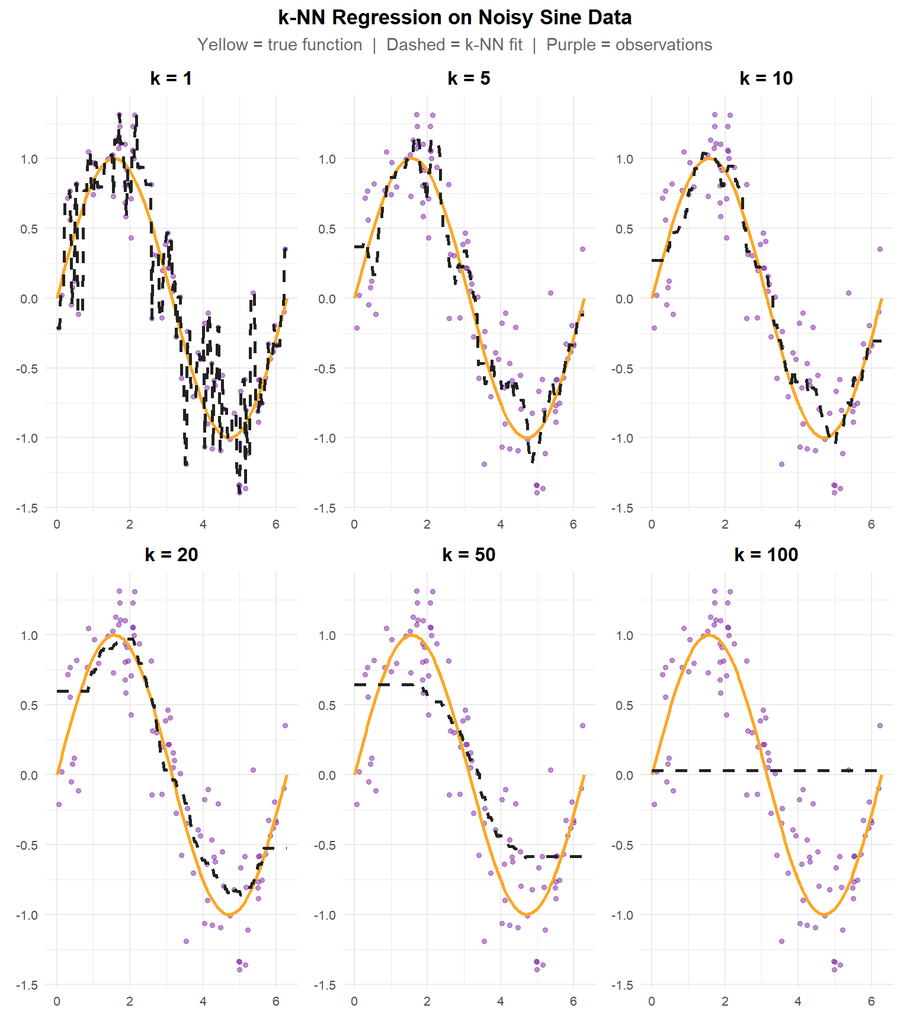

```r
set.seed(747)
n        <- 100
x_train  <- runif(n, 0, 2 * pi)
y_train  <- sin(x_train) + rnorm(n, sd = 0.3)
x_test   <- seq(0, 2 * pi, length.out = 200)
true_y   <- sin(x_test)

train_df <- data.frame(x = x_train, y = y_train)
test_df  <- data.frame(x = x_test)

k_values <- c(1, 5, 10, 20, 50, 100)

plots <- lapply(k_values, function(k) {
  fit  <- kknn(y ~ x, train = train_df, test = test_df,
               k = k, kernel = "rectangular")
  df   <- data.frame(x = x_test, true = true_y, pred = fit$fitted.values)
  obs  <- data.frame(x = x_train, y = y_train)

  ggplot() +
    geom_point(data = obs, aes(x = x, y = y),
               color = "#7B1FA2", alpha = 0.5, size = 1.2) +
    geom_line(data = df, aes(x = x, y = true),
              color = "#F9A825", linewidth = 1) +
    geom_line(data = df, aes(x = x, y = pred),
              color = "#212121", linewidth = 0.9, linetype = "dashed") +
    labs(title = paste0("k = ", k),
         x = NULL, y = NULL) +
    theme_minimal(base_size = 10) +
    theme(plot.title = element_text(hjust = 0.5, face = "bold"))
})

(plots[[1]] | plots[[2]] | plots[[3]]) /
(plots[[4]] | plots[[5]] | plots[[6]]) +
  plot_annotation(
    title    = "k-NN Regression on Noisy Sine Data",
    subtitle = "Yellow = true function  |  Dashed = k-NN fit  |  Purple = observations",
    theme    = theme(plot.title    = element_text(face = "bold", hjust = 0.5),
                     plot.subtitle = element_text(hjust = 0.5, color = "gray40"))
  )
```

At $k=1$ the fit is jagged and overfits noise; at $k=100$ the fit is flat and misses the sine shape entirely. The visual sweet spot is around $k = 10$–$20$.

# 3 Decision Boundary Comparison: 5-NN vs. LDA

## 3.1 Experimental Setup

We generate $n = 200$ points from two overlapping bivariate Gaussian classes:

$$\text{Class 1}: \mathbf{x} \sim
\mathcal{N}\!\left(\begin{bmatrix}0\\0\end{bmatrix},
\begin{bmatrix}1 & 0.5\\0.5 & 1\end{bmatrix}\right), \qquad
\text{Class 2}: \mathbf{x} \sim
\mathcal{N}\!\left(\begin{bmatrix}1.5\\1.5\end{bmatrix},
\begin{bmatrix}1 & 0.5\\0.5 & 1\end{bmatrix}\right)$$

Both classes share the **same covariance** $\Sigma$, which is exactly the assumption LDA encodes — making this a setting where LDA should be well-specified.

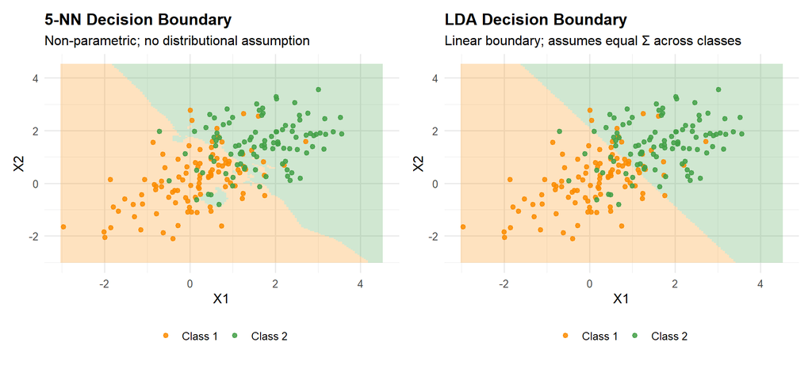

```r
set.seed(747)
n       <- 100
class_1 <- MASS::mvrnorm(n, mu = c(0,   0),   Sigma = matrix(c(1,0.5,0.5,1), 2))
class_2 <- MASS::mvrnorm(n, mu = c(1.5, 1.5), Sigma = matrix(c(1,0.5,0.5,1), 2))
data_df <- data.frame(
  rbind(class_1, class_2),
  Class = factor(rep(c("Class 1", "Class 2"), each = n))
)
names(data_df)[1:2] <- c("X1", "X2")

# Prediction grid
grid <- expand.grid(
  X1 = seq(-3, 4.5, length = 150),
  X2 = seq(-3, 4.5, length = 150)
)

# k-NN (k=5)
knn_fit      <- kknn(Class ~ X1 + X2, train = data_df, test = grid,
                     k = 5, kernel = "rectangular")
grid$knn_pred <- fitted(knn_fit)

# LDA
lda_fit      <- lda(Class ~ X1 + X2, data = data_df)
grid$lda_pred <- predict(lda_fit, newdata = grid)$class

cols <- c("Class 1" = "#FB8C00", "Class 2" = "#43A047")

p_knn <- ggplot() +
  geom_tile(data = grid, aes(x = X1, y = X2, fill = knn_pred),
            alpha = 0.25) +
  geom_point(data = data_df, aes(x = X1, y = X2, color = Class),
             size = 1.8, alpha = 0.85) +
  scale_fill_manual(values  = cols, guide = "none") +
  scale_color_manual(values = cols) +
  labs(title = "5-NN Decision Boundary",
       subtitle = "Non-parametric; no distributional assumption",
       color = NULL) +
  theme_minimal(base_size = 12) +
  theme(legend.position = "bottom",
        plot.title      = element_text(face = "bold"))

p_lda <- ggplot() +
  geom_tile(data = grid, aes(x = X1, y = X2, fill = lda_pred),
            alpha = 0.25) +
  geom_point(data = data_df, aes(x = X1, y = X2, color = Class),
             size = 1.8, alpha = 0.85) +
  scale_fill_manual(values  = cols, guide = "none") +
  scale_color_manual(values = cols) +
  labs(title = "LDA Decision Boundary",
       subtitle = "Linear boundary; assumes equal Σ across classes",
       color = NULL) +
  theme_minimal(base_size = 12) +
  theme(legend.position = "bottom",
        plot.title      = element_text(face = "bold"))

p_knn | p_lda
```

## 3.2 Interpretation

LDA produces a **linear** decision boundary — a hyperplane in $\mathbb{R}^2$ — derived analytically from the equal-covariance Gaussian assumption. Since the data-generating process satisfies exactly this assumption, LDA is the Bayes optimal classifier here (up to parameter estimation error).

5-NN produces a **nonlinear, locally-adaptive** boundary shaped by the training points. While flexible, it is more sensitive to local noise, and its boundary becomes erratic near class-overlap regions. In this equal-covariance setting, 5-NN slightly underperforms LDA.

**Key takeaway:** when the parametric assumptions are correct, LDA achieves lower test error with far fewer effective parameters. k-NN’s advantage emerges when the true boundary is nonlinear and/or the Gaussian assumption is violated.

# 4 Conclusion

| Concept | Key Result |
| --- | --- |
| Bias-Variance | Optimal k ≈ 20 for the sine experiment; $k=1$ overfits, $k=100$ underfits |
| k-NN vs. LDA | LDA produces a sharper, more stable boundary when equal-$\Sigma$ assumption holds |
| Practical guidance | Prefer LDA (or regularised variants) for low-$p$, roughly Gaussian data; k-NN for high-$p$ nonlinear settings |